# Difference-in-Differences Tutorial

Ohi Islam

2026-03-11

# 1 Overview

This tutorial introduces the difference-in-differences (DiD) method using a simple simulated example. We begin with visual intuition, then construct the DiD estimate from group averages, and finally connect the idea to a regression model.

# 2 Learning Goals

By the end of this tutorial, students should be able to:

- describe the logic of a DiD design
- compute a DiD estimate using average outcomes
- interpret the interaction term in a regression model
- connect graphical, tabular, and regression-based interpretations

# 3 Setup

```r
library(tidyverse)
library(knitr)
```

# 4 Visual Intuition

Suppose one group is exposed to a policy intervention and another group is not. We observe outcomes for both groups before and after the intervention.

```r
did_df <- tibble(
  group = c("Control", "Control", "Treatment", "Treatment"),
  period = c("Pre", "Post", "Pre", "Post"),
  outcome = c(50, 54, 48, 60)
)

did_df
```

```
## # A tibble: 4 × 3
##   group     period outcome
##   <chr>     <chr>    <dbl>
## 1 Control   Pre         50
## 2 Control   Post        54
## 3 Treatment Pre         48
## 4 Treatment Post        60
```

We can visualize these outcomes first.

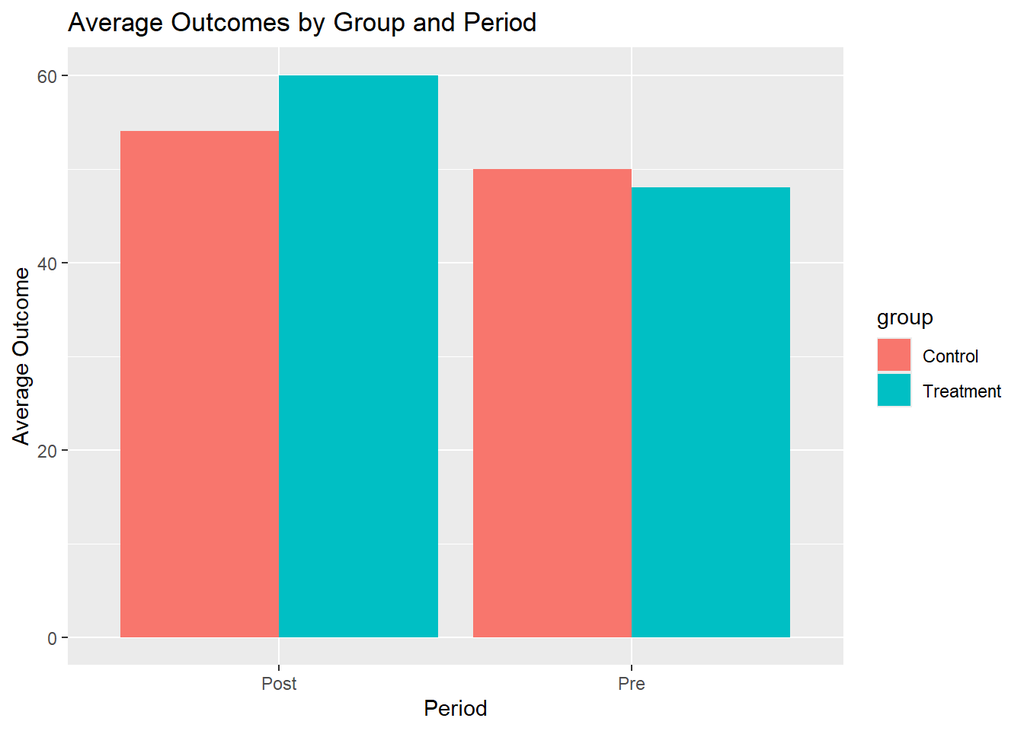

```r
ggplot(did_df, aes(x = period, y = outcome, fill = group)) +
  geom_col(position = "dodge") +
  labs(
    title = "Average Outcomes by Group and Period",
    x = "Period",
    y = "Average Outcome"
  )
```

The graph helps us compare how outcomes changed over time in the treatment and control groups.

# 5 Constructing the DiD Estimate

The DiD estimate compares:

1. the change in the treatment group
2. the change in the control group
3. the difference between those two changes

## 5.1 Step 1: Compute Within-Group Changes

```r
control_pre  <- 50
control_post <- 54
treat_pre    <- 48
treat_post   <- 60

control_change <- control_post - control_pre
treat_change   <- treat_post - treat_pre
did_estimate   <- treat_change - control_change

control_change
```

```
## [1] 4
```

```r
treat_change
```

```
## [1] 12
```

```r
did_estimate
```

```
## [1] 8
```

The control group changed by 4, and the treatment group changed by 12.

So the DiD estimate is:

$$(60 - 48) - (54 - 50) = 12 - 4 = 8$$

## 5.2 Step 2: Show the Calculation in a Table

```r
did_summary <- tibble(
  Group = c("Control", "Treatment"),
  Pre = c(control_pre, treat_pre),
  Post = c(control_post, treat_post),
  Change = c(control_change, treat_change)
)

kable(did_summary, caption = "Outcomes and Changes by Group")
```

Outcomes and Changes by Group

| Group | Pre | Post | Change |
| --- | --- | --- | --- |
| Control | 50 | 54 | 4 |
| Treatment | 48 | 60 | 12 |

This table shows that the treatment group improved more than the control group, and the extra improvement is the DiD estimate.

# 6 Regression Interpretation

We now connect this idea to a regression model.

$$Y_i = \beta_0 + \beta_1 \text{Treatment}_i + \beta_2 \text{Post}_i +
\beta_3 (\text{Treatment}_i \times \text{Post}_i) + \varepsilon_i$$

The coefficient $\beta_3$ is the DiD estimate.

## 6.1 Simulated Individual-Level Data

To fit the regression, we create a simple individual-level dataset that matches the same group averages.

```r
set.seed(123)

n <- 100

sim_df <- tibble(
  treatment = rep(c(0, 0, 1, 1), each = n),
  post = rep(c(0, 1, 0, 1), each = n),
  mean_outcome = c(
    rep(50, n),
    rep(54, n),
    rep(48, n),
    rep(60, n)
  )
) %>%
  mutate(
    outcome = rnorm(n = 4 * n, mean = mean_outcome, sd = 4)
  )

head(sim_df)
```

```
## # A tibble: 6 × 4
##   treatment  post mean_outcome outcome
##       <dbl> <dbl>        <dbl>   <dbl>
## 1         0     0           50    47.8
## 2         0     0           50    49.1
## 3         0     0           50    56.2
## 4         0     0           50    50.3
## 5         0     0           50    50.5
## 6         0     0           50    56.9
```

## 6.2 Estimate the DiD Regression

```r
did_model <- lm(outcome ~ treatment + post + treatment:post, data = sim_df)

summary(did_model)
```

```
##
## Call:
## lm(formula = outcome ~ treatment + post + treatment:post, data = sim_df)
##
## Residuals:
##     Min      1Q  Median      3Q     Max
## -9.7187 -2.6300 -0.1994  2.6781 13.3943
##
## Coefficients:
##                Estimate Std. Error t value Pr(>|t|)
## (Intercept)     50.3616     0.3873 130.040  < 2e-16 ***
## treatment       -1.8798     0.5477  -3.432 0.000662 ***
## post             3.2082     0.5477   5.858 9.88e-09 ***
## treatment:post   8.1651     0.7746  10.542  < 2e-16 ***
## ---
## Signif. codes:  0 '***' 0.001 '**' 0.01 '*' 0.05 '.' 0.1 ' ' 1
##
## Residual standard error: 3.873 on 396 degrees of freedom
## Multiple R-squared:  0.557,  Adjusted R-squared:  0.5536
## F-statistic:   166 on 3 and 396 DF,  p-value: < 2.2e-16
```

# 7 Interpreting the Coefficients

In this regression:

- the intercept is the average outcome for the control group in the pre period
- the coefficient on `treatment` is the difference between treatment and control in the pre period
- the coefficient on `post` is the change over time for the control group
- the coefficient on `treatment:post` is the DiD estimate

## 7.1 Extract the Key Coefficient

```r
coef(did_model)["treatment:post"]
```

```
## treatment:post
##       8.165059
```

This interaction coefficient represents the additional post-period change in the treated group relative to the control group.

# 8 Linking the Graph, Table, and Regression

The same treatment effect appears in three ways:

- in the graph, as the larger increase for the treatment group
- in the table, as the difference between the two group-specific changes
- in the regression, as the interaction coefficient

This is why the DiD framework is useful pedagogically: students can see the same idea visually, numerically, and econometrically.

# 9 Parallel Trends Assumption

For a DiD design to have a causal interpretation, we usually rely on the parallel trends assumption.

This means that, in the absence of treatment, the treatment and control groups would have followed similar trends over time.

This assumption cannot be tested directly for the treated post-treatment outcome, but researchers often examine pre-treatment trends and institutional context to assess whether it is plausible.

# 10 Conclusion

Difference-in-differences estimates the treatment effect by comparing changes over time across treated and untreated groups. The key parameter is the interaction between treatment status and the post-treatment period.

# 11 Optional Exercise

Try modifying the four group-period averages and see how the DiD estimate changes.

For example:

- increase the post-treatment outcome for the treatment group
- decrease the post-treatment outcome for the control group
- make both groups trend upward by the same amount

How does each change affect the DiD estimate?